# Lab 8 - Multiple linear regression

Lab 8 - Multiple linear regression CUNY MSDA DATA 606 Duubar Villalobos Jimenez mydvtech@gmail.com May 7, 2017

```r
library(knitr)
library(DATA606)
```

## Grading the professor

Many college courses conclude by giving students the opportunity to evaluate the course and the instructor anonymously. However, the use of these student evaluations as an indicator of course quality and teaching effectiveness is often criticized because these measures may reflect the influence of non-teaching related characteristics, such as the physical appearance of the instructor. The article titled, “Beauty in the classroom: instructors’ pulchritude and putative pedagogical productivity” (Hamermesh and Parker, 2005) found that instructors who are viewed to be better looking receive higher instructional ratings. (Daniel S. Hamermesh, Amy Parker, Beauty in the classroom: instructors pulchritude and putative pedagogical productivity, *Economics of Education Review*, Volume 24, Issue 4, August 2005, Pages 369-376, ISSN 0272-7757, 10.1016/j.econedurev.2004.07.013. http://www.sciencedirect.com/science/article/pii/S0272775704001165.)

In this lab we will analyze the data from this study in order to learn what goes into a positive professor evaluation.

## The data

The data were gathered from end of semester student evaluations for a large sample of professors from the University of Texas at Austin. In addition, six students rated the professors’ physical appearance. (This is slightly modified version of the original data set that was released as part of the replication data for *Data Analysis Using Regression and Multilevel/Hierarchical Models* (Gelman and Hill, 2007).) The result is a data frame where each row contains a different course and columns represent variables about the courses and professors.

```r
load("more/evals.RData")
```

| variable | description |
| --- | --- |
| `score` | average professor evaluation score: (1) very unsatisfactory - (5) excellent. |
| `rank` | rank of professor: teaching, tenure track, tenured. |
| `ethnicity` | ethnicity of professor: not minority, minority. |
| `gender` | gender of professor: female, male. |
| `language` | language of school where professor received education: english or non-english. |
| `age` | age of professor. |
| `cls_perc_eval` | percent of students in class who completed evaluation. |
| `cls_did_eval` | number of students in class who completed evaluation. |
| `cls_students` | total number of students in class. |
| `cls_level` | class level: lower, upper. |
| `cls_profs` | number of professors teaching sections in course in sample: single, multiple. |
| `cls_credits` | number of credits of class: one credit (lab, PE, etc.), multi credit. |
| `bty_f1lower` | beauty rating of professor from lower level female: (1) lowest - (10) highest. |
| `bty_f1upper` | beauty rating of professor from upper level female: (1) lowest - (10) highest. |
| `bty_f2upper` | beauty rating of professor from second upper level female: (1) lowest - (10) highest. |
| `bty_m1lower` | beauty rating of professor from lower level male: (1) lowest - (10) highest. |
| `bty_m1upper` | beauty rating of professor from upper level male: (1) lowest - (10) highest. |
| `bty_m2upper` | beauty rating of professor from second upper level male: (1) lowest - (10) highest. |
| `bty_avg` | average beauty rating of professor. |
| `pic_outfit` | outfit of professor in picture: not formal, formal. |
| `pic_color` | color of professor’s picture: color, black & white. |

## Exploring the data

1. Is this an observational study or an experiment? The original research question posed in the paper is whether beauty leads directly to the differences in course evaluations. Given the study design, is it possible to answer this question as it is phrased? If not, rephrase the question.

**Answer:**

This is an observational study. Experiments provide control and experimental groups and there’s none in this case.

In an observational study we cannot set causation between the explanatory and response variables; but to find a correlation instead.

A good question could be: Does the instructor’s physical appearance has impact to student course evaluation?

2. Describe the distribution of `score`. Is the distribution skewed? What does that tell you about how students rate courses? Is this what you expected to see? Why, or why not?

**Answer:**

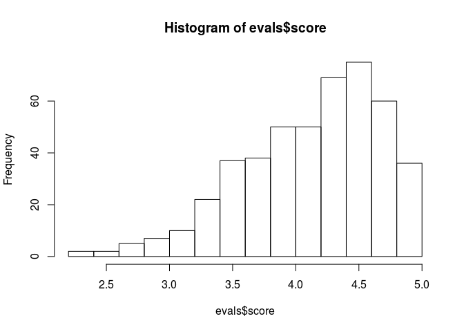

```r
hist(evals$score)
```

- Is the distribution skewed? Yes, the evaluation scores are `left skewed`.
- What does that tell you about how students rate courses?

- Is this what you expected to see? Why, or why not?

To be honest, I was not expecting any specific response. But from classroom experience, I would say that knowledge and kindness beauty transpose physical appearance providing extra factors to consider.

3. Excluding `score`, select two other variables and describe their relationship using an appropriate visualization (scatterplot, side-by-side boxplots, or mosaic plot).

**Answer:**

For this, I have selected `age` and `bty_avg`.

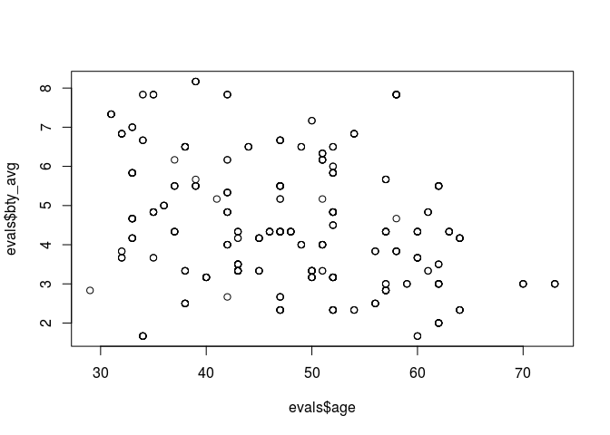

```r
plot(x = evals$age, y = evals$bty_avg)
```

Based on pure visualization, in the scatter plot there seems to be a negative relationship in between the two variables as the instructor gets older.

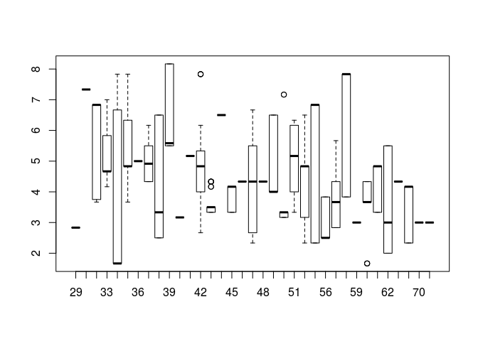

```r
boxplot(evals$bty_avg ~ evals$age)
```

By observing the boxplot, we noticed that some ages have a wide `bty_avg` range while others have a low range; in some cases we can notice some outliers on some of the grading ages.

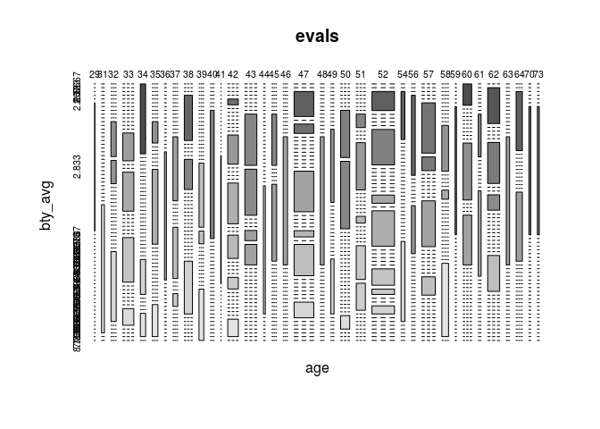

```r
mosaicplot(~ age + bty_avg , data = evals, color = TRUE)
```

By observing this mosaic plot, we can visually identify a few grading observations or when age groups were the most and less graded.

## Simple linear regression

The fundamental phenomenon suggested by the study is that better looking teachers are evaluated more favorably. Let’s create a scatterplot to see if this appears to be the case:

```r
plot(evals$score ~ evals$bty_avg)
```

[output not shown]

Before we draw conclusions about the trend, compare the number of observations in the data frame with the approximate number of points on the scatterplot. Is anything awry?

**Answer:**

```r
nrow(evals)
```

```
## [1] 463
```

The number of observations are $463$; however there seems to be less than 463 points in the scattered plot.

4. Replot the scatterplot, but this time use the function `jitter()` on the $y$- or the $x$-coordinate. (Use `?jitter` to learn more.) What was misleading about the initial scatterplot?

**Answer:**

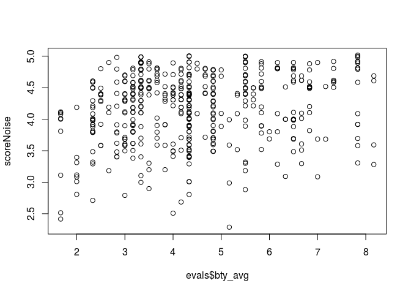

```r
scoreNoise <- jitter(evals$score, factor = 1, amount = NULL)
plot(scoreNoise ~ evals$bty_avg)
```

It seems that the original scattered plot was plotting only one point representing the score mean of the points that were very near to each other; providing a misrepresentation of the whole scattered plot since many point were hidden.

5. Let’s see if the apparent trend in the plot is something more than natural variation. Fit a linear model called `m_bty` to predict average professor score by average beauty rating and add the line to your plot using `abline(m_bty)`. Write out the equation for the linear model and interpret the slope. Is average beauty score a statistically significant predictor? Does it appear to be a practically significant predictor?

**Answer:**

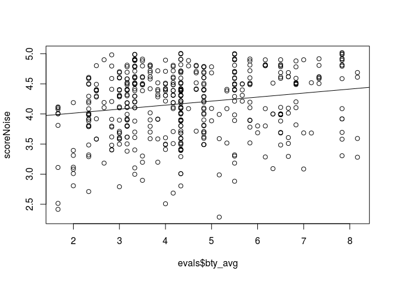

```r
m_bty <- lm(evals$score ~ evals$bty_avg)
plot(scoreNoise ~ evals$bty_avg)
abline(m_bty)
```

**Find Correlation**

```r
scorNbty_Cor <- cor(evals$score, evals$bty_avg)
```

The correlation in between the `score` and `bty_avg` is: 0.1871424.

```r
summary(m_bty)
```

```
##
## Call:
## lm(formula = evals$score ~ evals$bty_avg)
##
## Residuals:
##     Min      1Q  Median      3Q     Max
## -1.9246 -0.3690  0.1420  0.3977  0.9309
##
## Coefficients:
##               Estimate Std. Error t value Pr(>|t|)
## (Intercept)    3.88034    0.07614   50.96  < 2e-16 ***
## evals$bty_avg  0.06664    0.01629    4.09 5.08e-05 ***
## ---
## Signif. codes:  0 '***' 0.001 '**' 0.01 '*' 0.05 '.' 0.1 ' ' 1
##
## Residual standard error: 0.5348 on 461 degrees of freedom
## Multiple R-squared:  0.03502,    Adjusted R-squared:  0.03293
## F-statistic: 16.73 on 1 and 461 DF,  p-value: 5.083e-05
```

The equation for the linear model is: $\hat{y} = 3.88034 + 0.06664 \cdot bty\_avg$

- Is average beauty score a statistically significant predictor?

Yes, `bty_avg` is a statistically significant predictor of evaluation score with p-value close of $0$.

- Does it appear to be a practically significant predictor?

It appears not to be a practically significant predictor of evaluation score since for every $1$ point increase in `bty_ave`, the model only predicts an increase of $0.06664$. this is not a very significant change in the evaluation score, hence is not a significant predictor.

6. Use residual plots to evaluate whether the conditions of least squares regression are reasonable. Provide plots and comments for each one (see the Simple Regression Lab for a reminder of how to make these).

**Answer:**

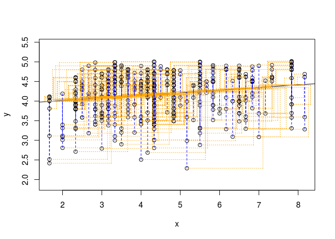

```
## Click two points to make a line.

## Call:
## lm(formula = y ~ x, data = pts)
##
## Coefficients:
## (Intercept)            x
##     3.87991      0.06665
##
## Sum of Squares:  132.05
```

```r
plot_ss(x = evals$bty_avg, y = scoreNoise, showSquares = TRUE)
```

When fitting a least squares line, we generally require:

`Linearity`: *“The data should show a linear trend”*

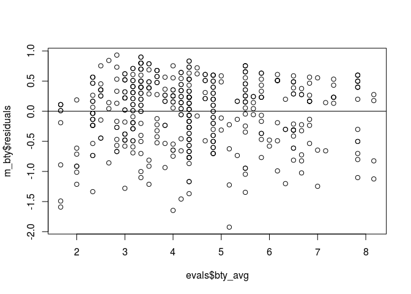

```r
plot(m_bty$residuals ~ evals$bty_avg)
abline(h = 0)
```

The relationship looks linear. By looking at the residual plot as the variability of residuals is approximately constant across the distribution but does not indicate any curvatures or any indication of non-normality.

`Nearly normal residuals`: *“Generally the residuals must be nearly normal. When this condition is found to be unreasonable, it is usually because of outliers or concerns about influential points”*.

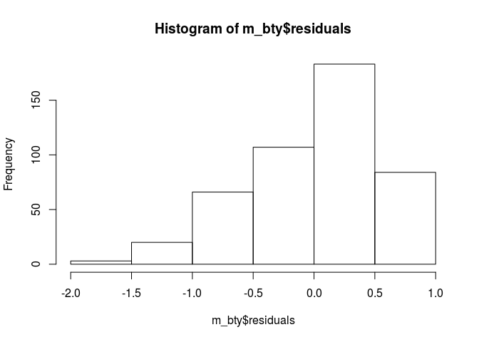

```r
hist(m_bty$residuals)
```

By looking at the histogram we can observe that the residuals do not follow some sort of normality in respect to their frequency distribution. In this case, this condition is **NOT** met.

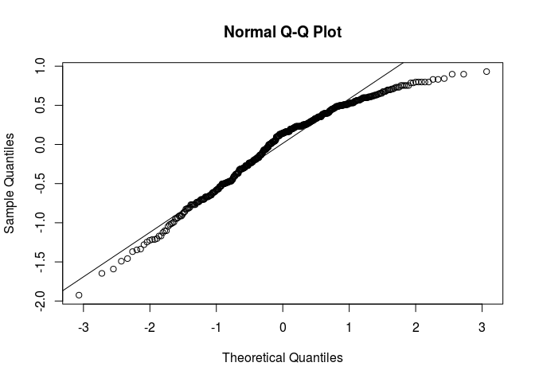

```r
qqnorm(m_bty$residuals)
qqline(m_bty$residuals)
```

And by looking at the Q-Q Plot, we can observe how the distribution is **NOT** following around a straight line. hence we can conclude that this model does not satisfies the nearly normal residuals condition.

`Constant variability`: *“The variability of points around the least squares line remains roughly constant”*. Based on the plot the variability of points around the least squares line remains roughly constant so the condition constant variability has been met.

`Independent observations`: We can considered this to be met since is this observational study represents less than 10% of the population.

Since one of the conditions of least squares regression is not met; we conclude that this regression method is not satisfactory for considering `avg_bty` as a predictor of `score`.

## Multiple linear regression

The data set contains several variables on the beauty score of the professor: individual ratings from each of the six students who were asked to score the physical appearance of the professors and the average of these six scores. Let’s take a look at the relationship between one of these scores and the average beauty score.

```r
plot(evals$bty_avg ~ evals$bty_f1lower)
cor(evals$bty_avg, evals$bty_f1lower)
```

[output not shown]

As expected the relationship is quite strong - after all, the average score is calculated using the individual scores. We can actually take a look at the relationships between all beauty variables (columns 13 through 19) using the following command:

```r
plot(evals[,13:19])
```

[output not shown]

These variables are collinear (correlated), and adding more than one of these variables to the model would not add much value to the model. In this application and with these highly-correlated predictors, it is reasonable to use the average beauty score as the single representative of these variables.

In order to see if beauty is still a significant predictor of professor score after we’ve accounted for the gender of the professor, we can add the gender term into the model.

```r
m_bty_gen <- lm(score ~ bty_avg + gender, data = evals)
summary(m_bty_gen)
```

```
##
## Call:
## lm(formula = score ~ bty_avg + gender, data = evals)
##
## Residuals:
##     Min      1Q  Median      3Q     Max
## -1.8305 -0.3625  0.1055  0.4213  0.9314
##
## Coefficients:
##             Estimate Std. Error t value Pr(>|t|)
## (Intercept)  3.74734    0.08466  44.266  < 2e-16 ***
## bty_avg      0.07416    0.01625   4.563 6.48e-06 ***
## gendermale   0.17239    0.05022   3.433 0.000652 ***
## ---
## Signif. codes:  0 '***' 0.001 '**' 0.01 '*' 0.05 '.' 0.1 ' ' 1
##
## Residual standard error: 0.5287 on 460 degrees of freedom
## Multiple R-squared:  0.05912,    Adjusted R-squared:  0.05503
## F-statistic: 14.45 on 2 and 460 DF,  p-value: 8.177e-07
```

7. P-values and parameter estimates should only be trusted if the conditions for the regression are reasonable. Verify that the conditions for this model are reasonable using diagnostic plots.

**Answer:**

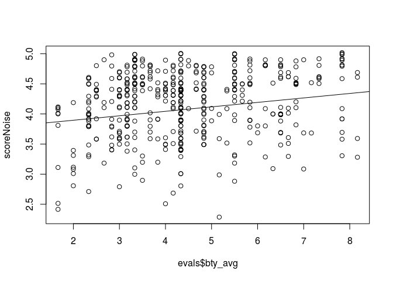

```r
plot(scoreNoise ~ evals$bty_avg)
abline(m_bty_gen)
```

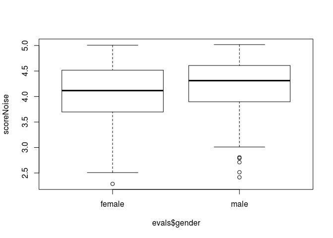

```r
plot(scoreNoise ~ evals$gender)
```

When fitting a least squares line, we generally require:

`Nearly normal residuals`: *“Generally the residuals must be nearly normal. When this condition is found to be unreasonable, it is usually because of outliers or concerns about influential points”*.

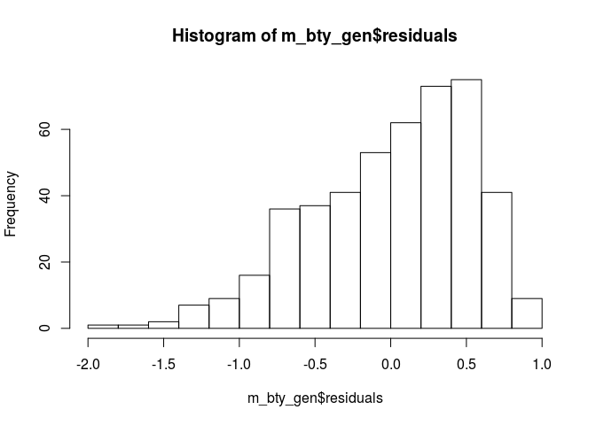

```r
hist(m_bty_gen$residuals)
```

By looking at the histogram we can observe that the residuals seems not to follow some sort of normality in respect to their frequency distribution.

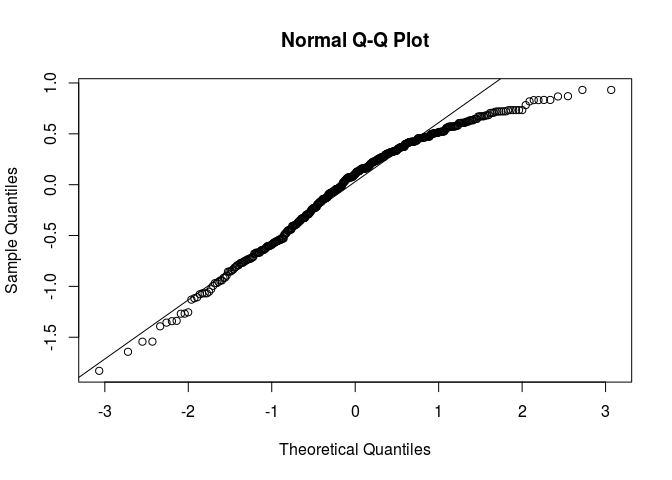

```r
qqnorm(m_bty_gen$residuals)
qqline(m_bty_gen$residuals)
```

And by looking at the Q-Q Plot, we can observe how the distribution tends to follow around a straight line but then it deviates due to outliers.

`Constant variability`: *“The variability of points around the least squares line remains roughly constant”*. Based on the plot the variability of points around the least squares line remains roughly constant so the condition constant variability has been met.

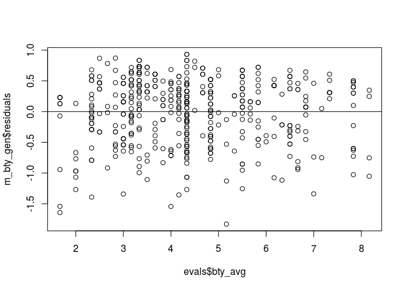

```r
plot(m_bty_gen$residuals ~ evals$bty_avg)
abline(h = 0)
```

`Independent observations`: We can considered this to be met since is this observational study represents less than 10% of the population.

8. Is `bty_avg` still a significant predictor of `score`? Has the addition of `gender` to the model changed the parameter estimate for `bty_avg`?

**Answer:** Yes, `bty_avg` is a significant predictor. With the addition of `gender` it has added even more significance since the p-value became smaller.

Note that the estimate for `gender` is now called `gendermale`. You’ll see this name change whenever you introduce a categorical variable. The reason is that R recodes `gender` from having the values of `female` and `male` to being an indicator variable called `gendermale` that takes a value of $0$ for females and a value of $1$ for males. (Such variables are often referred to as “dummy” variables.)

As a result, for females, the parameter estimate is multiplied by zero, leaving the intercept and slope form familiar from simple regression.

$$\begin{aligned}
\widehat{score} &= \hat{\beta}_0 + \hat{\beta}_1 \times bty\_avg + \hat{\beta}_2 \times (0) \\
&= \hat{\beta}_0 + \hat{\beta}_1 \times bty\_avg\end{aligned}$$

We can plot this line and the line corresponding to males with the following custom function.

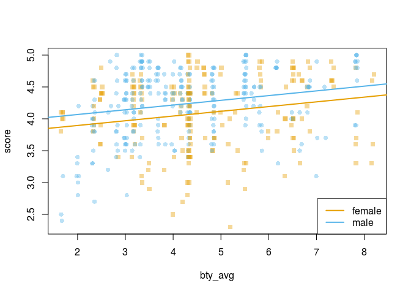

```r
multiLines(m_bty_gen)
```

9. What is the equation of the line corresponding to males? (*Hint:* For males, the parameter estimate is multiplied by 1.) For two professors who received the same beauty rating, which gender tends to have the higher course evaluation score?

**Answer:**

```r
summary(m_bty_gen)
```

```
##
## Call:
## lm(formula = score ~ bty_avg + gender, data = evals)
##
## Residuals:
##     Min      1Q  Median      3Q     Max
## -1.8305 -0.3625  0.1055  0.4213  0.9314
##
## Coefficients:
##             Estimate Std. Error t value Pr(>|t|)
## (Intercept)  3.74734    0.08466  44.266  < 2e-16 ***
## bty_avg      0.07416    0.01625   4.563 6.48e-06 ***
## gendermale   0.17239    0.05022   3.433 0.000652 ***
## ---
## Signif. codes:  0 '***' 0.001 '**' 0.01 '*' 0.05 '.' 0.1 ' ' 1
##
## Residual standard error: 0.5287 on 460 degrees of freedom
## Multiple R-squared:  0.05912,    Adjusted R-squared:  0.05503
## F-statistic: 14.45 on 2 and 460 DF,  p-value: 8.177e-07
```

Since the gender `male` can be represented with $1$. From the original equation we have as follows:

$\widehat{score} = \hat{\beta}_0 + \hat{\beta}_1 \times bty\_avg + \hat{\beta}_2 \times Male$

$\widehat{score} = 3.74734 + 0.07416 \times bty\_avg + 0.17239 \times 1$

$\widehat{score} = 3.91973 + 0.07416 \times bty\_avg$

For two professors who received the same beauty rating, which gender tends to have the higher course evaluation score?

In this predictive model, Male professors will receive the highest score by 0.17239.

The decision to call the indicator variable `gendermale` instead of`genderfemale` has no deeper meaning. R simply codes the category that comes first alphabetically as a $0$. (You can change the reference level of a categorical variable, which is the level that is coded as a 0, using the`relevel` function. Use `?relevel` to learn more.)

10. Create a new model called `m_bty_rank` with `gender` removed and `rank` added in. How does R appear to handle categorical variables that have more than two levels? Note that the rank variable has three levels: `teaching`, `tenure track`, `tenured`.

```r
m_bty_rank <- lm(score ~ bty_avg + rank, data = evals)
summary(m_bty_rank)
```

```
##
## Call:
## lm(formula = score ~ bty_avg + rank, data = evals)
##
## Residuals:
##     Min      1Q  Median      3Q     Max
## -1.8713 -0.3642  0.1489  0.4103  0.9525
##
## Coefficients:
##                  Estimate Std. Error t value Pr(>|t|)
## (Intercept)       3.98155    0.09078  43.860  < 2e-16 ***
## bty_avg           0.06783    0.01655   4.098 4.92e-05 ***
## ranktenure track -0.16070    0.07395  -2.173   0.0303 *
## ranktenured      -0.12623    0.06266  -2.014   0.0445 *
## ---
## Signif. codes:  0 '***' 0.001 '**' 0.01 '*' 0.05 '.' 0.1 ' ' 1
##
## Residual standard error: 0.5328 on 459 degrees of freedom
## Multiple R-squared:  0.04652,    Adjusted R-squared:  0.04029
## F-statistic: 7.465 on 3 and 459 DF,  p-value: 6.88e-05
```

The interpretation of the coefficients in multiple regression is slightly different from that of simple regression. The estimate for `bty_avg` reflects how much higher a group of professors is expected to score if they have a beauty rating that is one point higher *while holding all other variables constant*. In this case, that translates into considering only professors of the same rank with `bty_avg` scores that are one point apart.

## The search for the best model

We will start with a full model that predicts professor score based on rank, ethnicity, gender, language of the university where they got their degree, age, proportion of students that filled out evaluations, class size, course level, number of professors, number of credits, average beauty rating, outfit, and picture color.

11. Which variable would you expect to have the highest p-value in this model? Why? *Hint:* Think about which variable would you expect to not have any association with the professor score.

**Answer:** Language; since we are evaluating the physical appearance of the instructor; the language should not have a major association with the professor score.

Let’s run the model…

```r
m_full <- lm(score ~ rank + ethnicity + gender + language + age + cls_perc_eval
             + cls_students + cls_level + cls_profs + cls_credits + bty_avg
             + pic_outfit + pic_color, data = evals)
summary(m_full)
```

```
##
## Call:
## lm(formula = score ~ rank + ethnicity + gender + language + age +
##     cls_perc_eval + cls_students + cls_level + cls_profs + cls_credits +
##     bty_avg + pic_outfit + pic_color, data = evals)
##
## Residuals:
##      Min       1Q   Median       3Q      Max
## -1.77397 -0.32432  0.09067  0.35183  0.95036
##
## Coefficients:
##                         Estimate Std. Error t value Pr(>|t|)
## (Intercept)            4.0952141  0.2905277  14.096  < 2e-16 ***
## ranktenure track      -0.1475932  0.0820671  -1.798  0.07278 .
## ranktenured           -0.0973378  0.0663296  -1.467  0.14295
## ethnicitynot minority  0.1234929  0.0786273   1.571  0.11698
## gendermale             0.2109481  0.0518230   4.071 5.54e-05 ***
## languagenon-english   -0.2298112  0.1113754  -2.063  0.03965 *
## age                   -0.0090072  0.0031359  -2.872  0.00427 **
## cls_perc_eval          0.0053272  0.0015393   3.461  0.00059 ***
## cls_students           0.0004546  0.0003774   1.205  0.22896
## cls_levelupper         0.0605140  0.0575617   1.051  0.29369
## cls_profssingle       -0.0146619  0.0519885  -0.282  0.77806
## cls_creditsone credit  0.5020432  0.1159388   4.330 1.84e-05 ***
## bty_avg                0.0400333  0.0175064   2.287  0.02267 *
## pic_outfitnot formal  -0.1126817  0.0738800  -1.525  0.12792
## pic_colorcolor        -0.2172630  0.0715021  -3.039  0.00252 **
## ---
## Signif. codes:  0 '***' 0.001 '**' 0.01 '*' 0.05 '.' 0.1 ' ' 1
##
## Residual standard error: 0.498 on 448 degrees of freedom
## Multiple R-squared:  0.1871, Adjusted R-squared:  0.1617
## F-statistic: 7.366 on 14 and 448 DF,  p-value: 6.552e-14
```

12. Check your suspicions from the previous exercise. Include the model output in your response.

**Answer:**

The highest p value for this model is $0.77806$ for `cls_profs`.

The p value for the variable I was expecting to be the highest is $0.03965$ for `language`; which is a big difference in between the two of them.

13. Interpret the coefficient associated with the ethnicity variable.

**Answer:**

By considering all other variables being equal; the score for instructors that are **not minority** tends to be $0.1234929$ higher.

14. Drop the variable with the highest p-value and re-fit the model. Did the coefficients and significance of the other explanatory variables change? (One of the things that makes multiple regression interesting is that coefficient estimates depend on the other variables that are included in the model.) If not, what does this say about whether or not the dropped variable was collinear with the other explanatory variables?

**Answer:**

```r
m_full1 <- lm(score ~ rank + ethnicity + gender + language + age + cls_perc_eval
             + cls_students + cls_level + cls_credits + bty_avg
             + pic_outfit + pic_color, data = evals)
summary(m_full1)
```

```
##
## Call:
## lm(formula = score ~ rank + ethnicity + gender + language + age +
##     cls_perc_eval + cls_students + cls_level + cls_credits +
##     bty_avg + pic_outfit + pic_color, data = evals)
##
## Residuals:
##     Min      1Q  Median      3Q     Max
## -1.7836 -0.3257  0.0859  0.3513  0.9551
##
## Coefficients:
##                         Estimate Std. Error t value Pr(>|t|)
## (Intercept)            4.0872523  0.2888562  14.150  < 2e-16 ***
## ranktenure track      -0.1476746  0.0819824  -1.801 0.072327 .
## ranktenured           -0.0973829  0.0662614  -1.470 0.142349
## ethnicitynot minority  0.1274458  0.0772887   1.649 0.099856 .
## gendermale             0.2101231  0.0516873   4.065 5.66e-05 ***
## languagenon-english   -0.2282894  0.1111305  -2.054 0.040530 *
## age                   -0.0089992  0.0031326  -2.873 0.004262 **
## cls_perc_eval          0.0052888  0.0015317   3.453 0.000607 ***
## cls_students           0.0004687  0.0003737   1.254 0.210384
## cls_levelupper         0.0606374  0.0575010   1.055 0.292200
## cls_creditsone credit  0.5061196  0.1149163   4.404 1.33e-05 ***
## bty_avg                0.0398629  0.0174780   2.281 0.023032 *
## pic_outfitnot formal  -0.1083227  0.0721711  -1.501 0.134080
## pic_colorcolor        -0.2190527  0.0711469  -3.079 0.002205 **
## ---
## Signif. codes:  0 '***' 0.001 '**' 0.01 '*' 0.05 '.' 0.1 ' ' 1
##
## Residual standard error: 0.4974 on 449 degrees of freedom
## Multiple R-squared:  0.187,  Adjusted R-squared:  0.1634
## F-statistic: 7.943 on 13 and 449 DF,  p-value: 2.336e-14
```

```r
m_full$coefficients == m_full1$coefficients
```

```
##           (Intercept)      ranktenure track           ranktenured
##                 FALSE                 FALSE                 FALSE
## ethnicitynot minority            gendermale   languagenon-english
##                 FALSE                 FALSE                 FALSE
##                   age         cls_perc_eval          cls_students
##                 FALSE                 FALSE                 FALSE
##        cls_levelupper       cls_profssingle cls_creditsone credit
##                 FALSE                 FALSE                 FALSE
##               bty_avg  pic_outfitnot formal        pic_colorcolor
##                 FALSE                 FALSE                 FALSE
```

Did the coefficients and significance of the other explanatory variables change?

**Yes**, the coefficients changed, which means the dropped variable depends on other variables as well.

15. Using backward-selection and p-value as the selection criterion, determine the best model. You do not need to show all steps in your answer, just the output for the final model. Also, write out the linear model for predicting score based on the final model you settle on.

**Answer:**

```r
m_full2 <- lm(score ~ gender + language + age + cls_perc_eval
             + cls_credits + bty_avg + pic_color, data = evals)
summary(m_full2)
```

```
##
## Call:
## lm(formula = score ~ gender + language + age + cls_perc_eval +
##     cls_credits + bty_avg + pic_color, data = evals)
##
## Residuals:
##      Min       1Q   Median       3Q      Max
## -1.81919 -0.32035  0.09272  0.38526  0.88213
##
## Coefficients:
##                        Estimate Std. Error t value Pr(>|t|)
## (Intercept)            3.967255   0.215824  18.382  < 2e-16 ***
## gendermale             0.221457   0.049937   4.435 1.16e-05 ***
## languagenon-english   -0.281933   0.098341  -2.867  0.00434 **
## age                   -0.005877   0.002622  -2.241  0.02551 *
## cls_perc_eval          0.004295   0.001432   2.999  0.00286 **
## cls_creditsone credit  0.444392   0.100910   4.404 1.33e-05 ***
## bty_avg                0.048679   0.016974   2.868  0.00432 **
## pic_colorcolor        -0.216556   0.066625  -3.250  0.00124 **
## ---
## Signif. codes:  0 '***' 0.001 '**' 0.01 '*' 0.05 '.' 0.1 ' ' 1
##
## Residual standard error: 0.5014 on 455 degrees of freedom
## Multiple R-squared:  0.1631, Adjusted R-squared:  0.1502
## F-statistic: 12.67 on 7 and 455 DF,  p-value: 6.996e-15
```

```r
score <- function(gender, language, age, cls_perc_eval, cls_credits, bty_avg, pic_color){

score <-( 3.967255
        + 0.221457 * gender
        - 0.281933 * language
        - 0.005877 * age
        + 0.004295 * cls_perc_eval
        + 0.444392 * cls_credits
        + 0.048679 * bty_avg
        - 0.216556 * pic_color)

return(round(score,1))

}

backwardSelection <- score(1, 1, evals$age, evals$cls_perc_eval, 1, evals$bty_avg, 1)

compareScores <- data.frame(evals$score, backwardSelection, backwardSelection - evals$score)
names(compareScores) <- c("Original", "Prediction", "Difference")
```

```r
kable(head(compareScores,20))
```

| Original | Prediction | Difference |
| --- | --- | --- |
| 4.7 | 4.4 | -0.3 |
| 4.1 | 4.5 | 0.4 |
| 3.9 | 4.4 | 0.5 |
| 4.8 | 4.4 | -0.4 |
| 4.6 | 4.3 | -0.3 |
| 4.3 | 4.3 | 0.0 |
| 2.8 | 4.3 | 1.5 |
| 4.1 | 4.4 | 0.3 |
| 3.4 | 4.2 | 0.8 |
| 4.5 | 4.4 | -0.1 |
| 3.8 | 4.4 | 0.6 |
| 4.5 | 4.5 | 0.0 |
| 4.6 | 4.4 | -0.2 |
| 3.9 | 4.3 | 0.4 |
| 3.9 | 4.4 | 0.5 |
| 4.3 | 4.4 | 0.1 |
| 4.5 | 4.4 | -0.1 |
| 4.8 | 4.7 | -0.1 |
| 4.6 | 4.7 | 0.1 |
| 4.6 | 4.6 | 0.0 |

16. Verify that the conditions for this model are reasonable using diagnostic plots.

**Answer:**

- By looking at the histogram:

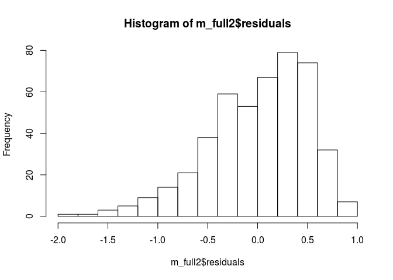

```r
hist(m_full2$residuals)
```

- Normal Probability Plot

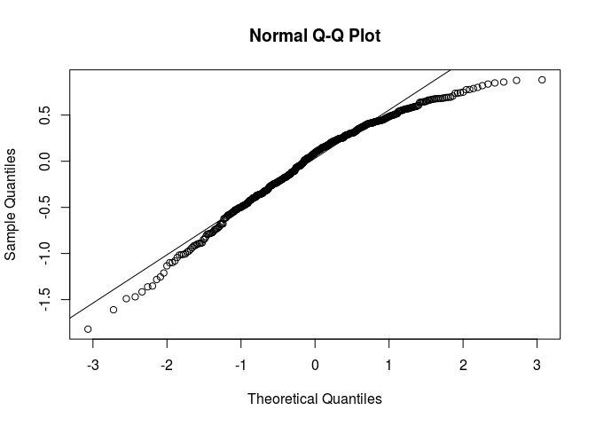

```r
qqnorm(m_full2$residuals)
qqline(m_full2$residuals)
```

- Gender

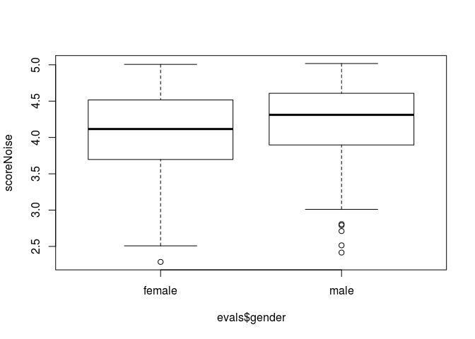

```r
plot(scoreNoise ~ evals$gender)
```

- Language

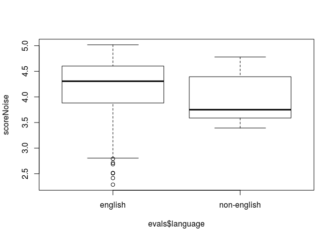

```r
plot(scoreNoise ~ evals$language)
```

- Age

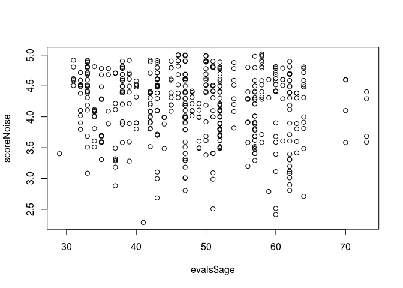

```r
plot(scoreNoise ~ evals$age)
```

- cls_perc_eval

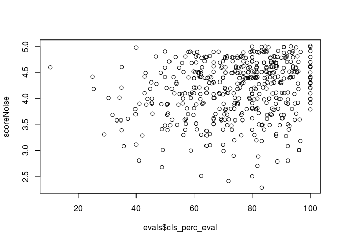

```r
plot(scoreNoise ~ evals$cls_perc_eval)
```

- Class Credits

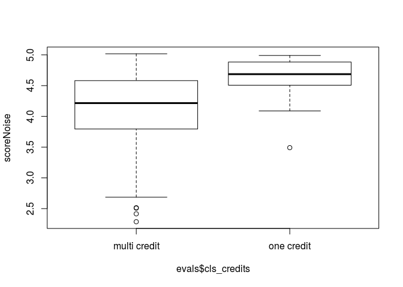

```r
plot(scoreNoise ~ evals$cls_credits)
```

- bty_avg

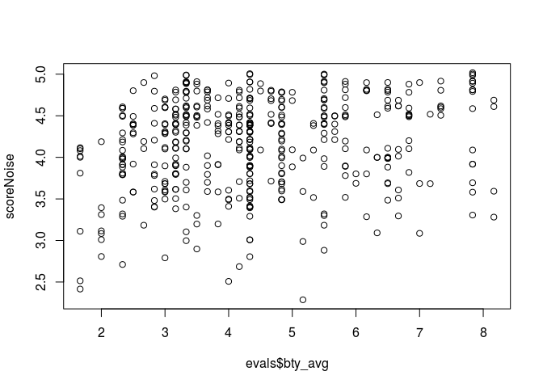

```r
plot(scoreNoise ~ evals$bty_avg)
```

- Pic Color

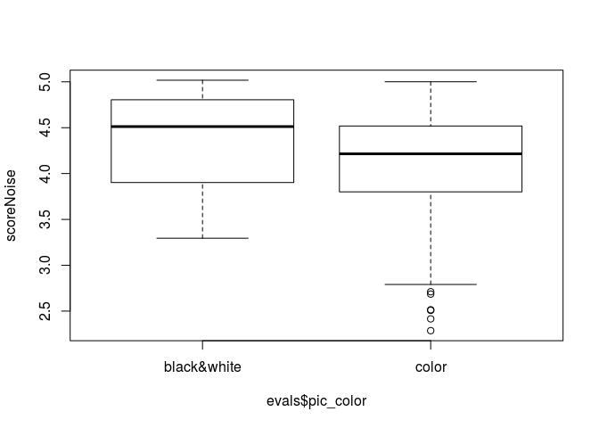

```r
plot(scoreNoise ~ evals$pic_color)
```

The variables above are related to the score.

17. The original paper describes how these data were gathered by taking a sample of professors from the University of Texas at Austin and including all courses that they have taught. Considering that each row represents a course, could this new information have an impact on any of the conditions of linear regression?

**Answer:**

From perspective, class courses are independent of each other. By having this condition of independence, evaluation scores from one course is independent of the other. If an instructor teaches more than one course it should not affect, however if the same student takes two or more classes with the same instructor this will affect the outcome since independence will not be satisfied.

18. Based on your final model, describe the characteristics of a professor and course at University of Texas at Austin that would be associated with a high evaluation score.

**Answer:**

Based on this model, the characteristics of the highest scores will be obtained by male instructors who obtained their degree in an english speaking university, teach one credit class and has a black and white picture.

19. Would you be comfortable generalizing your conclusions to apply to professors generally (at any university)? Why or why not?

**Answer:**

No, this report was not conducted as an experiment but based on an observational study in one given university. Also, the definition of beauty has changed over time, cultural values also change, these results may be different in other geographically different university or in a different time frame.

This is a product of OpenIntro that is released under a [Creative Commons Attribution-ShareAlike 3.0 Unported](http://creativecommons.org/licenses/by-sa/3.0). This lab was written by Mine Çetinkaya-Rundel and Andrew Bray.